# gluing to together interactive ux with automated testing

[@tonyfast](https://github.com/tonyfast) s notebooks

**title**

gluing to together interactive ux with automated testing

**description**

generate our accessible version of table and test it against the nu validator and axe.

**cells**

8 total

3 code

**state**

executed out of order

**kernel**

Python [conda env:p311] *

**language**

python

**name**

`conda-env-p311-py`

**lines of code**

25

**outputs**

3

In [ ]

markdown

actions

[output not shown]

9

# gluing to together interactive ux with automated testing

generate our accessible version of table and test it against the nu validator and axe.

this is important to post because it densely demonstrates an interactive computing activity for testing accessibility backed by automated testing.

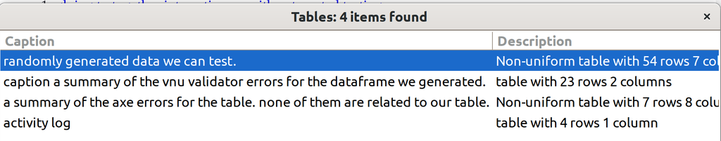

this work hits on a long time issue i've been wrestling with where [dataframes are a challenge from screen readers](https://github.com/Iota-School/notebooks-for-all/issues/18) .

In [ ]

markdown

actions

```
## our `nbconvert_a11y` table representations
```

1

## our table representations

In [ 4 ]

code

actions

```
from nbconvert_a11y.tables import get_table, Config
from nbconvert_a11y.axe import async_axe

(df := pandas.concat(dict(zip("ab", ([
    DataFrame(numpy.random.randn(50, 3)),
    DataFrame(numpy.random.randn(50, 3))
]))), axis=1))
df = df.set_index(df.index)
(table := get_table(df, Config(group_columns=True, group_index=True), caption="randomly generated data we can test."))
```

9

randomly generated data we can test.

[output not shown]

In [ ]

markdown

actions

```
## vnu checker

test the quality of the table against the table
```

3

## vnu checker

test the quality of the table against the table

In [ 5 ]

code

actions

```
validator = DataFrame(await async_axe.validate_html(
    str(table)
)).messages.series()
validator.groupby("message").count()[["type"]].pipe(get_table, caption="caption a summary of the vnu validator errors for the dataframe we generated.")
```

4

caption a summary of the vnu validator errors for the dataframe we generated.

| message | type |
| --- | --- |
| Attribute “aria-colspan” is unnecessary for elements that have attribute “colspan”. | 8 |
| Attribute “aria-rowspan” is unnecessary for elements that have attribute “rowspan”. | 2 |
| Bad value “True” for attribute “aria-hidden” on element “span”. | 1 |
| Bad value “colheader” for attribute “role” on element “th”. | 38 |
| Bad value “rowheader” for attribute “role” on element “th”. | 2 |
| Consider adding a “lang” attribute to the “html” start tag to declare the language of this document. | 1 |
| Element “head” is missing a required instance of child element “title”. | 1 |
| Element “td” is missing one or more of the following attributes: “role”. | 1 |
| Start tag seen without seeing a doctype first. Expected “<!DOCTYPE html>”. | 1 |
| Table cell spans past the end of its row group established by a “tbody” element; clipped to the end of the row group. | 2 |
| The “cell” role is unnecessary for element “td”. | 132 |
| The “role” attribute must not be used on a “td” element which has a “table” ancestor with no “role” attribute, or with a “role” attribute whose value is “table”, “grid”, or “treegrid”. | 132 |
| The “role” attribute must not be used on a “th” element which has a “table” ancestor with no “role” attribute, or with a “role” attribute whose value is “table”, “grid”, or “treegrid”. | 40 |
| The “role” attribute must not be used on a “tr” element which has a “table” ancestor with no “role” attribute, or with a “role” attribute whose value is “table”, “grid”, or “treegrid”. | 27 |
| The “rowgroup” role is unnecessary for element “tbody”. | 3 |
| The “rowgroup” role is unnecessary for element “tfoot”. | 1 |
| The “rowgroup” role is unnecessary for element “thead”. | 1 |
| The “rowheader” role is unnecessary for element “th”. | 2 |
| The “row” role is unnecessary for element “tr”. | 27 |
| The “table” role is unnecessary for element “table”. | 1 |
| message | type |
| min | 1 |
| max | 132 |

In [ ]

markdown

actions

```
## axe checker
```

1

## axe checker

In [ 6 ]

code

actions

```
Series((await async_axe.validate_axe(str(table))).get("violations")).series().set_index("id").groupby("impact").pipe(
    get_table, caption="a summary of the axe errors for the table. none of them are related to our table.", config=Config(group_index=True)
)
```

3

a summary of the axe errors for the table. none of them are related to our table.

[output not shown]

In [ ]

markdown

actions

```
this might be one of the most naturally accessible documents i've written.
```

1

this might be one of the most naturally accessible documents i've written.